# Credit_card_FE_Python_more_examples-1

### Oklahoma purchase credit card transactions project

The Office of Management and Enterprise Services in the State of Oklahoma has made its purchase credit card transactions available. This dataset contains information on purchases made through the purchase card programs administered by the state and higher education institutions.

- **[Section 1 Data Preparation](#1)**
  - 1.1 Create Data Fields
- **[Section 2 Initial observations and Feature Engineering](#2)**
- **[Feature Engineering-----Merchant Part](#3)**
  - 2.1 Feature 1: The ratio to average amount
  - 2.2 Feature 2: The ratio to median amount
  - 2.3 Feature 3: The ratio to average amount by month period
  - 2.4 Feature 4: The ratio to median amount by month period
  - 2.5 Feature 5: The ratio to average amount by day of week
  - 2.6 Feature 6: The ratio to median amount by day of week
  - 2.7 Feature 7: Merchant popularity: Total transaction
- **[Feature Engineering-----Cardholder Part](#4)**
  - 2.8 Feature 8: The ratio to average amount
  - 2.9 Feature 9: The ratio to median amount
  - 2.10 Feature 10: The ratio to average amount by month
  - 2.11 Feature 11: The ratio to median amount by month
  - 2.12 Feature 12: Number of Transaction ratio for a course of month in the year
  - 2.13 Feature 13: Number of Transaction ratio for a course of week in the month
- **[Feature Engineering-----Both Merchant and Cardholder Part](#5)**
  - 2.14 Feature 14: The ratio to average amount
  - 2.15 Feature 15: The ratio to median amount
- **[Feature Engineering-----Improved/revised features](#59)**
  - 2.16 Feature 16: z-score to average amount of Merchant Part
  - 2.17 Feature 17: z-score to average amount of Merchant Part by month
  - 2.18 Feature 18: z-score to average amount of Cardholder Part
  - 2.19 Feature 19: z-score to average amount of Cardholder Part by month
  - 2.20 Feature 20: z-score to average amount of both Merchant and Cardholder Part
- **[Section 3 KNNs](#6)**

## Section 1 Data Preparation

```python
import pandas as pd
df = pd.read_csv('purchase_credit_card.csv') #, encoding = "ISO-8859-1")
df.tail(5)
```

|  | Year-Month | Agency Number | Agency Name | Cardholder Last Name | Cardholder First Initial | Description | Amount | Vendor | Transaction Date | Posted Date | Merchant Category Code (MCC) |
| --- | --- | --- | --- | --- | --- | --- | --- | --- | --- | --- | --- |
| 442453 | 201406 | 98000 | GRAND RIVER DAM AUTH. | Cardholder | e | GENERAL PURCHASE | 992.00 | TOTAL VALVE SYSTEMS | 06/20/2014 12:00:00 AM | 06/23/2014 12:00:00 AM | HARDWARE EQUIPMENT AND SUPPLIES |
| 442454 | 201406 | 98000 | GRAND RIVER DAM AUTH. | Cardholder | e | GENERAL PURCHASE | 2415.00 | PRYOR WASTE & RECYCLING L | 06/20/2014 12:00:00 AM | 06/23/2014 12:00:00 AM | UTILITIES - ELECTRIC,GAS,WATER,SANITARY |
| 442455 | 201406 | 98000 | GRAND RIVER DAM AUTH. | Cardholder | e | GENERAL PURCHASE | 177.50 | ACCURATE ENVIROMENTAL LAB | 06/20/2014 12:00:00 AM | 06/23/2014 12:00:00 AM | BUSINESS SERVICES NOT ELSEWHERE CLASSIFIED |
| 442456 | 201406 | 98000 | GRAND RIVER DAM AUTH. | Cardholder | e | GENERAL PURCHASE | 32457.00 | RED BUD SERVICE INC | 06/19/2014 12:00:00 AM | 06/23/2014 12:00:00 AM | PROFESSIONAL SERVICES NOT ELSEWHERE CLASSIFIED |
| 442457 | 201406 | 98000 | GRAND RIVER DAM AUTH. | Cardholder | e | GENERAL PURCHASE | 4714.07 | WARRENCAT CREDIT DEPT | 06/20/2014 12:00:00 AM | 06/23/2014 12:00:00 AM | MISCELLANEOUS AND SPECIALTY RETAIL STORES |

```python
# check dimensions of the dataset, we found it has 442,458 rows and 11 columns
print(df.shape)
print(df.columns) # check column names
df.describe() # Get the Simple Summary Statistics
```

```
(442458, 11)
Index(['Year-Month', 'Agency Number', 'Agency Name', 'Cardholder Last Name',
       'Cardholder First Initial', 'Description', 'Amount', 'Vendor',
       'Transaction Date', 'Posted Date', 'Merchant Category Code (MCC)'],
      dtype='object')
```

|  | Year-Month | Agency Number | Amount |
| --- | --- | --- | --- |
| count | 442458.000000 | 442458.000000 | 4.424580e+05 |
| mean | 201357.284375 | 42785.860353 | 4.249912e+02 |
| std | 47.107417 | 33378.461293 | 5.266509e+03 |
| min | 201307.000000 | 1000.000000 | -4.286304e+04 |
| 25% | 201309.000000 | 1000.000000 | 3.091000e+01 |
| 50% | 201401.000000 | 47700.000000 | 1.048900e+02 |
| 75% | 201404.000000 | 76000.000000 | 3.450000e+02 |
| max | 201406.000000 | 98000.000000 | 1.903858e+06 |

```python
# change column names
df.columns = ['Year_Month', 'Agency_Number', 'Agency_Name', 'Cardholder_Last_Name',
      'Cardholder_First_Initial', 'Description', 'Amount', 'Vendor', 'Transaction_Date',
      'Posted_Date', 'Merchant_Category']
```

### 1.1 Create date fields

```python
#Creating separate Year and Month columns for future feature engineering
# Converting Transaction_Date and Posted_date from Python Object data type to datetime
df['Transaction_Date']=pd.to_datetime(df['Transaction_Date'])
df['Posted_Date']=pd.to_datetime(df['Posted_Date'])

df['Year_Month'].dtype
df['Year_Month']=pd.to_datetime(df['Year_Month'], format='%Y%m')
df['Year'] = df['Year_Month'].dt.year
df['Month'] = df['Year_Month'].dt.month
#Creating 'Week_Number' from 'Transaction_Date'
df['Week_Number'] = df['Transaction_Date'].dt.isocalendar().week

#Creating 'Day_of_Week' from 'Transaction_Date'
dayOfWeek={0:'Monday', 1:'Tuesday', 2:'Wednesday', 3:'Thursday', 4:'Friday', 5:'Saturday', 6:'Sunday'}
df['Day_of_Week'] = df['Transaction_Date'].dt.dayofweek.map(dayOfWeek)

df['Day_of_Week'].value_counts()
```

```
Wednesday    89644
Thursday     87537
Tuesday      86919
Friday       79917
Monday       61809
Saturday     26307
Sunday       10325
Name: Day_of_Week, dtype: int64
```

```python
df.head()
```

|  | Year_Month | Agency_Number | Agency_Name | Cardholder_Last_Name | Cardholder_First_Initial | Description | Amount | Vendor | Transaction_Date | Posted_Date | Merchant_Category | Year | Month | Week_Number | Day_of_Week |
| --- | --- | --- | --- | --- | --- | --- | --- | --- | --- | --- | --- | --- | --- | --- | --- |
| 0 | 2013-07-01 | 1000 | OKLAHOMA STATE UNIVERSITY | Mason | C | GENERAL PURCHASE | 890.00 | NACAS | 2013-07-30 | 2013-07-31 | CHARITABLE AND SOCIAL SERVICE ORGANIZATIONS | 2013 | 7 | 31 | Tuesday |
| 1 | 2013-07-01 | 1000 | OKLAHOMA STATE UNIVERSITY | Mason | C | ROOM CHARGES | 368.96 | SHERATON HOTEL | 2013-07-30 | 2013-07-31 | SHERATON | 2013 | 7 | 31 | Tuesday |
| 2 | 2013-07-01 | 1000 | OKLAHOMA STATE UNIVERSITY | Massey | J | GENERAL PURCHASE | 165.82 | SEARS.COM 9300 | 2013-07-29 | 2013-07-31 | DIRCT MARKETING/DIRCT MARKETERS--NOT ELSEWHERE... | 2013 | 7 | 31 | Monday |
| 3 | 2013-07-01 | 1000 | OKLAHOMA STATE UNIVERSITY | Massey | T | GENERAL PURCHASE | 96.39 | WAL-MART #0137 | 2013-07-30 | 2013-07-31 | GROCERY STORES,AND SUPERMARKETS | 2013 | 7 | 31 | Tuesday |
| 4 | 2013-07-01 | 1000 | OKLAHOMA STATE UNIVERSITY | Mauro-Herrera | M | HAMMERMILL COPY PLUS COPY EA | 125.96 | STAPLES DIRECT | 2013-07-30 | 2013-07-31 | STATIONERY, OFFICE SUPPLIES, PRINTING AND WRIT... | 2013 | 7 | 31 | Tuesday |

## Section 2 Initial observations and Feature Engineering

```python
#!pip install plotly
```

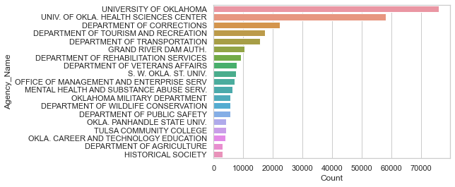

```python
import numpy as np
import plotly
import pandas as pd
import plotly.express as px

# Summarize the count statistics by agency_name in df_count
df_count = df['Agency_Name'].value_counts()
df_count = pd.DataFrame(df_count).reset_index()
df_count.columns = ['Agency_Name','Count']

fig = px.bar(df_count, x='Agency_Name', y='Count', color = 'Agency_Name', width=1000, height=400)
import seaborn as sns
sns.set_theme(style="whitegrid")
sns.barplot(y="Agency_Name", x="Count", data=df_count[1:20])
```

## Feature Engineering-----Merchant Part

#### Instructions:

- Understand the data grain: each row is a cardholder (last name + first name)
- An agency can have multiple cardholders. A corporate card (agency_name) can be used by many cardholders and these cardholders have to follow the corporation policy.
- Intuition: One or two cardholders may abuse their corporate cards. If we compare a cardholder to his agency, we can find outliers.
- The spending for a merchant category can be higher than others. It does not make sense to compare the spending of a merchant category to another. An agency can spend on various merchant categories, and you cannot claim anomalies just because the spending on one merchant category is higher than another.
- Anomaly detection is about "comparing a transaction to a benchmark". What is the right benchmark?
- So we will aggregate to the Aggrecy_Name level and card holder level then build features.
- Common sense tells us the comparison should be at "Agency_Name" and "Merchant_Category" level.

### 2.1 Feature 1: The ratio to average amount by agency and merchant catagory

```python
# create average spending group by agency and merchant category
stat_by_agency = df.groupby(['Agency_Name', 'Merchant_Category'])['Amount'].mean()
stat_by_agency = pd.DataFrame(stat_by_agency)
stat_by_agency.columns = ['AVG_amount']
stat_by_agency
```

| Agency_Name | Merchant_Category | AVG_amount |
| --- | --- | --- |
| ARDMORE HIGHER EDUCATION CENTER | BUSINESS SERVICES NOT ELSEWHERE CLASSIFIED | 115.120000 |
|  | CATALOG MERCHANTS | -53.344286 |
|  | COMPUTER NETWORK/INFORMATION SERVICES | 18.340000 |
|  | DRUG STORES AND PHARMACIES | 153.450000 |
|  | GROCERY STORES,AND SUPERMARKETS | 74.525455 |
| ... | ... | ... |
| `DEPARTMENT OF EDUCATION | TELECOMMUNICATION SERVICES | 118.054000 |
|  | TRAVEL AGENCIES | 24.253731 |
|  | TROPICANA RESORT AND CASINO | 481.600000 |
|  | UNITED AIRLINES | 310.547368 |
|  | WYNDHAM HOTELS | 93.282857 |

8427 rows × 1 columns

```python
# add the new feature average spending to the dataset
df1 = pd.merge(df, stat_by_agency, how='left', on=['Agency_Name', 'Merchant_Category'])
# Feature 1: ratio of amount spending and avergae spending by merchant category
df1['agency_merchant_avg_ratio_amount'] = np.where(df1['AVG_amount']==0,0, df1['Amount'] / df1['AVG_amount'])
df1['agency_merchant_avg_ratio_amount'].describe()
```

```
count    442458.000000
mean          0.999724
std           7.225363
min       -2735.680000
25%           0.177145
50%           0.515301
75%           1.102916
max        2735.680000
Name: agency_merchant_avg_ratio_amount, dtype: float64
```

#### My thought process:

- The above percentile motivates me to cut by percentile for plotting
- Do you notice some transactions can be 2 times of the average. Could they be anomalies?

```python
# cut by percentile for plotting
var = 'agency_merchant_avg_ratio_amount'
binned_var = var + '_D'
percentile = [0,0.01,0.05,0.2,0.5,0.8,0.95,0.99,1]
df1[binned_var] = pd.qcut( df1[var],percentile)
df1[['agency_merchant_avg_ratio_amount_D']]
```

|  | agency_merchant_avg_ratio_amount_D |
| --- | --- |
| 0 | (1.298, 3.515] |
| 1 | (0.515, 1.298] |
| 2 | (0.133, 0.515] |
| 3 | (1.298, 3.515] |
| 4 | (0.133, 0.515] |
| ... | ... |
| 442453 | (0.515, 1.298] |
| 442454 | (0.133, 0.515] |
| 442455 | (0.0212, 0.133] |
| 442456 | (8.71, 2735.68] |
| 442457 | (1.298, 3.515] |

442458 rows × 1 columns

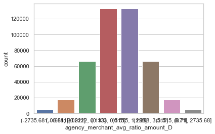

```python
sns.countplot(x="agency_merchant_avg_ratio_amount_D", data=df1)
```

#### Thought process:

- It will be ideal if the x label does not overlap with each other.
- Try to rotate it.

```
[Text(0, 0, '(-2735.681, -0.681]'),
```

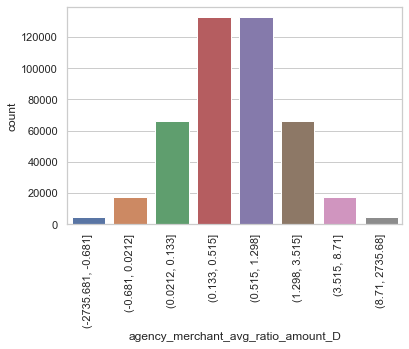

```python
import matplotlib.pyplot as plt
plt.figure(figsize=(6,4))
g = sns.countplot(x="agency_merchant_avg_ratio_amount_D", data=df1)
g.set_xticklabels(g.get_xticklabels(), rotation=90)
```

#### Thought process:

- Now we have identified extreme spending compared to the same merchant category.
- Take a look of them.

```python
df1[df1['agency_merchant_avg_ratio_amount']>2].head()
```

|  | Year_Month | Agency_Number | Agency_Name | Cardholder_Last_Name | Cardholder_First_Initial | Description | Amount | Vendor | Transaction_Date | Posted_Date | Merchant_Category | Year | Month | Week_Number | Day_of_Week | AVG_amount | agency_merchant_avg_ratio_amount | agency_merchant_avg_ratio_amount_D |
| --- | --- | --- | --- | --- | --- | --- | --- | --- | --- | --- | --- | --- | --- | --- | --- | --- | --- | --- |
| 0 | 2013-07-01 | 1000 | OKLAHOMA STATE UNIVERSITY | Mason | C | GENERAL PURCHASE | 890.00 | NACAS | 2013-07-30 | 2013-07-31 | CHARITABLE AND SOCIAL SERVICE ORGANIZATIONS | 2013 | 7 | 31 | Tuesday | 427.634060 | 2.081219 | (1.298, 3.515] |
| 16 | 2013-07-01 | 1000 | OKLAHOMA STATE UNIVERSITY | Mohiuddin | I | GENERAL PURCHASE | 2425.00 | WESTERN EQUIPMENT ALVA | 2013-07-29 | 2013-07-31 | HARDWARE STORES | 2013 | 7 | 31 | Monday | 170.060436 | 14.259636 | (8.71, 2735.68] |
| 17 | 2013-07-01 | 1000 | OKLAHOMA STATE UNIVERSITY | Mohiuddin | I | GENERAL PURCHASE | 2425.00 | WESTERN EQUIPMENT ALVA | 2013-07-29 | 2013-07-31 | HARDWARE STORES | 2013 | 7 | 31 | Monday | 170.060436 | 14.259636 | (8.71, 2735.68] |
| 33 | 2013-07-01 | 1000 | OKLAHOMA STATE UNIVERSITY | Gerlt | T | GENERAL PURCHASE | 3582.00 | TELVENT | 2013-07-26 | 2013-07-29 | BUSINESS SERVICES NOT ELSEWHERE CLASSIFIED | 2013 | 7 | 30 | Friday | 392.641168 | 9.122833 | (8.71, 2735.68] |
| 35 | 2013-07-01 | 1000 | OKLAHOMA STATE UNIVERSITY | GODSEY | R | GENERAL PURCHASE | 407.85 | OPTIMUM ENERGY PROD | 2013-07-26 | 2013-07-29 | HARDWARE STORES | 2013 | 7 | 30 | Friday | 170.060436 | 2.398265 | (1.298, 3.515] |

### 2.2 Feature 2: The ratio to the median amount by agency and merchant catagory

- Notice the only difference to the above code is "median".

```python
# create median spending group by agency and merchant category
stat_by_agency = df.groupby(['Agency_Name', 'Merchant_Category'])['Amount'].median()
stat_by_agency = pd.DataFrame(stat_by_agency)
stat_by_agency.columns = ['Median_amount']
```

```python
# add the new feature median spending to the dataset
df2 = pd.merge(df, stat_by_agency, how='left', on=['Agency_Name', 'Merchant_Category'])
# Feature 1: ratio of amount spending and median spending by merchant category
df2['agency_merchant_median_ratio_amount'] = np.where(df2['Median_amount']==0,0, df2['Amount'] / df2['Median_amount'])
df2['agency_merchant_median_ratio_amount'].describe()
```

```
count    442458.000000
mean          4.952685
std        1078.581350
min       -1003.176471
25%           0.466090
50%           1.000000
75%           2.121102
max      528116.052705
Name: agency_merchant_median_ratio_amount, dtype: float64
```

```python
# cut by percentile for plotting
var = 'agency_merchant_median_ratio_amount'
binned_var = var + '_D'
percentile = [0,0.01,0.05,0.2,0.5,0.8,0.95,0.99,1]
df2[binned_var] = pd.qcut( df2[var],percentile)
```

```
[Text(0, 0, '(-1003.177, -1.121]'),
```

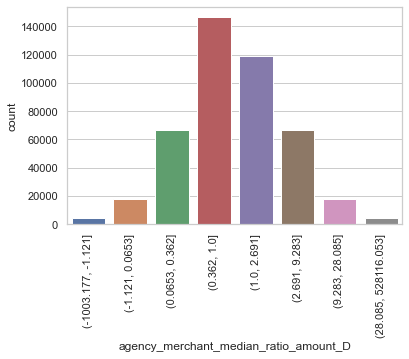

```python
import matplotlib.pyplot as plt
plt.figure(figsize=(6,4))
g = sns.countplot(x="agency_merchant_median_ratio_amount_D", data=df2)
g.set_xticklabels(g.get_xticklabels(), rotation=90)
```

```python
df2[df2['agency_merchant_median_ratio_amount']>2].head()
```

|  | Year_Month | Agency_Number | Agency_Name | Cardholder_Last_Name | Cardholder_First_Initial | Description | Amount | Vendor | Transaction_Date | Posted_Date | Merchant_Category | Year | Month | Week_Number | Day_of_Week | Median_amount | agency_merchant_median_ratio_amount | agency_merchant_median_ratio_amount_D |
| --- | --- | --- | --- | --- | --- | --- | --- | --- | --- | --- | --- | --- | --- | --- | --- | --- | --- | --- |
| 0 | 2013-07-01 | 1000 | OKLAHOMA STATE UNIVERSITY | Mason | C | GENERAL PURCHASE | 890.00 | NACAS | 2013-07-30 | 2013-07-31 | CHARITABLE AND SOCIAL SERVICE ORGANIZATIONS | 2013 | 7 | 31 | Tuesday | 250.000 | 3.560000 | (2.691, 9.283] |
| 3 | 2013-07-01 | 1000 | OKLAHOMA STATE UNIVERSITY | Massey | T | GENERAL PURCHASE | 96.39 | WAL-MART #0137 | 2013-07-30 | 2013-07-31 | GROCERY STORES,AND SUPERMARKETS | 2013 | 7 | 31 | Tuesday | 32.485 | 2.967216 | (2.691, 9.283] |
| 5 | 2013-07-01 | 1000 | OKLAHOMA STATE UNIVERSITY | Mauro-Herrera | M | GENERAL PURCHASE | 394.28 | KYOCERA DOCUMENT SOLUTION | 2013-07-29 | 2013-07-31 | OFFICE, PHOTOGRAPHIC, PHOTOCOPY, AND MICROFILM... | 2013 | 7 | 31 | Monday | 181.940 | 2.167088 | (1.0, 2.691] |
| 12 | 2013-07-01 | 1000 | OKLAHOMA STATE UNIVERSITY | McLemore | A | GENERAL PURCHASE | 572.27 | GIDDINGS MACHINE CO. | 2013-07-30 | 2013-07-31 | COMMERCIAL EQUIPMENT, NOT ELSEWHERE CLASSIFIED | 2013 | 7 | 31 | Tuesday | 187.000 | 3.060267 | (2.691, 9.283] |
| 14 | 2013-07-01 | 1000 | OKLAHOMA STATE UNIVERSITY | Meints | K | GENERAL PURCHASE | 445.00 | OK DEPT OF VO-TECH ED | 2013-07-30 | 2013-07-31 | GOVERNMENT SERVICES--NOT ELSEWHERE CLASSIFIED | 2013 | 7 | 31 | Tuesday | 91.500 | 4.863388 | (2.691, 9.283] |

##### Questions for you:

- You have created two features. Can you create more? How about by agency + merchant category + month?
- You have features in df1, df2, df3, etc. Can you merge the features into one data frame so in the future you can do modeling?

```python
#combine df1 and df2 into one data frame df
df['AVG_amount_MerchantPart'] = df1['AVG_amount']
df['agency_merchant_avg_ratio_amount']=df1['agency_merchant_avg_ratio_amount']
df['agency_merchant_avg_ratio_amount_D']=df1['agency_merchant_avg_ratio_amount_D']
df['agency_merchant_avg_median_amount']=df2['agency_merchant_median_ratio_amount']
df['agency_merchant_avg_median_amount_D']=df2['agency_merchant_median_ratio_amount_D']
df.head()
```

|  | Year_Month | Agency_Number | Agency_Name | Cardholder_Last_Name | Cardholder_First_Initial | Description | Amount | Vendor | Transaction_Date | Posted_Date | Merchant_Category | Year | Month | Week_Number | Day_of_Week | AVG_amount_MerchantPart | agency_merchant_avg_ratio_amount | agency_merchant_avg_ratio_amount_D | agency_merchant_avg_median_amount | agency_merchant_avg_median_amount_D |
| --- | --- | --- | --- | --- | --- | --- | --- | --- | --- | --- | --- | --- | --- | --- | --- | --- | --- | --- | --- | --- |
| 0 | 2013-07-01 | 1000 | OKLAHOMA STATE UNIVERSITY | Mason | C | GENERAL PURCHASE | 890.00 | NACAS | 2013-07-30 | 2013-07-31 | CHARITABLE AND SOCIAL SERVICE ORGANIZATIONS | 2013 | 7 | 31 | Tuesday | 427.634060 | 2.081219 | (1.298, 3.515] | 3.560000 | (2.691, 9.283] |
| 1 | 2013-07-01 | 1000 | OKLAHOMA STATE UNIVERSITY | Mason | C | ROOM CHARGES | 368.96 | SHERATON HOTEL | 2013-07-30 | 2013-07-31 | SHERATON | 2013 | 7 | 31 | Tuesday | 378.629890 | 0.974461 | (0.515, 1.298] | 1.407761 | (1.0, 2.691] |
| 2 | 2013-07-01 | 1000 | OKLAHOMA STATE UNIVERSITY | Massey | J | GENERAL PURCHASE | 165.82 | SEARS.COM 9300 | 2013-07-29 | 2013-07-31 | DIRCT MARKETING/DIRCT MARKETERS--NOT ELSEWHERE... | 2013 | 7 | 31 | Monday | 392.459376 | 0.422515 | (0.133, 0.515] | 0.966824 | (0.362, 1.0] |
| 3 | 2013-07-01 | 1000 | OKLAHOMA STATE UNIVERSITY | Massey | T | GENERAL PURCHASE | 96.39 | WAL-MART #0137 | 2013-07-30 | 2013-07-31 | GROCERY STORES,AND SUPERMARKETS | 2013 | 7 | 31 | Tuesday | 59.832149 | 1.611007 | (1.298, 3.515] | 2.967216 | (2.691, 9.283] |
| 4 | 2013-07-01 | 1000 | OKLAHOMA STATE UNIVERSITY | Mauro-Herrera | M | HAMMERMILL COPY PLUS COPY EA | 125.96 | STAPLES DIRECT | 2013-07-30 | 2013-07-31 | STATIONERY, OFFICE SUPPLIES, PRINTING AND WRIT... | 2013 | 7 | 31 | Tuesday | 271.213133 | 0.464432 | (0.133, 0.515] | 1.143895 | (1.0, 2.691] |

### 2.3 Feature 3: The ratio to average amount by month period

```python
# create average spending group by agency and merchant category every month
stat_by_agency = df.groupby(['Agency_Name', 'Merchant_Category','Month'])['Amount'].mean()
stat_by_agency = pd.DataFrame(stat_by_agency)
stat_by_agency.columns = ['AVG_amount']
stat_by_agency
```

| Agency_Name | Merchant_Category | Month | AVG_amount |
| --- | --- | --- | --- |
| ARDMORE HIGHER EDUCATION CENTER | BUSINESS SERVICES NOT ELSEWHERE CLASSIFIED | 11 | 115.120000 |
|  | CATALOG MERCHANTS | 7 | -637.750000 |
|  |  | 8 | 669.080000 |
|  |  | 9 | -334.540000 |
|  |  | 10 | 334.540000 |
| ... | ... | ... | ... |
| `DEPARTMENT OF EDUCATION | UNITED AIRLINES | 9 | 260.450000 |
|  |  | 10 | 523.800000 |
|  |  | 12 | 199.633333 |
|  | WYNDHAM HOTELS | 1 | 0.000000 |
|  |  | 12 | 130.596000 |

39888 rows × 1 columns

```python
# add the new feature average spending to the dataset
df3 = pd.merge(df, stat_by_agency, how='left', on=['Agency_Name', 'Merchant_Category','Month'])
# Feature 3: ratio of amount spending and avergae spending by merchant category
df3['agency_merchant_avg_month_ratio_amount'] = np.where(df3['AVG_amount']==0,0, df3['Amount'] / df3['AVG_amount'])
df3['agency_merchant_avg_month_ratio_amount'].describe()
```

```
count    4.424580e+05
mean     9.991488e-01
std      5.961952e+13
min     -2.447706e+16
25%      2.017647e-01
50%      5.984763e-01
75%      1.125213e+00
max      3.059633e+16
Name: agency_merchant_avg_month_ratio_amount, dtype: float64
```

```python
# cut by percentile for plotting
var = 'agency_merchant_avg_month_ratio_amount'
binned_var = var + '_D'
percentile = [0,0.01,0.05,0.2,0.5,0.8,0.95,0.99,1]
df3[binned_var] = pd.qcut(df3[var],percentile)
df3[['agency_merchant_avg_month_ratio_amount_D']]
```

|  | agency_merchant_avg_month_ratio_amount_D |
| --- | --- |
| 0 | (1.34, 3.417] |
| 1 | (0.598, 1.34] |
| 2 | (0.151, 0.598] |
| 3 | (1.34, 3.417] |
| 4 | (0.151, 0.598] |
| ... | ... |
| 442453 | (0.151, 0.598] |
| 442454 | (0.151, 0.598] |
| 442455 | (0.0239, 0.151] |
| 442456 | (8.05, 3.0596329968448308e+16] |
| 442457 | (3.417, 8.05] |

442458 rows × 1 columns

```
[Text(0, 0, '(-2.4477063974758644e+16, -0.734]'),
```

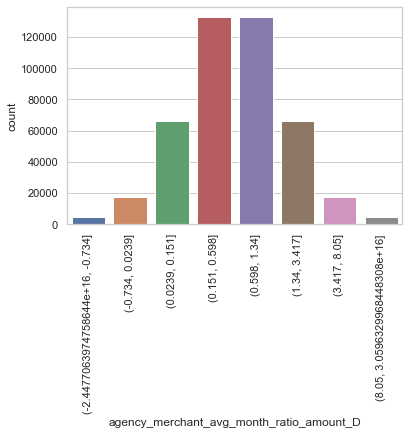

```python
import matplotlib.pyplot as plt
plt.figure(figsize=(6,4))
g = sns.countplot(x="agency_merchant_avg_month_ratio_amount_D", data=df3)
g.set_xticklabels(g.get_xticklabels(), rotation=90)
```

```python
#combine df3 into one data frame df
df['AVG_amount_MerchantPart_month'] = df3['AVG_amount']
df['agency_merchant_avg_month_ratio_amount']=df3['agency_merchant_avg_month_ratio_amount']
df['agency_merchant_avg_month_ratio_amount_D']=df3['agency_merchant_avg_month_ratio_amount_D']
```

#### Conclusion:

The top 1% transation has 0.7 times differnce in the ratio to average amount of whole transaction or transation within the same month. It is necessary to add the month into consideration.